# AOOI3_Aula07_DiagramasClassesDominio

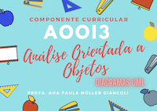

Instituto Federal de São Paulo (IFSP)  
[Campus Bragança Paulista/SP](https://bra.ifsp.edu.br)  
**Análise e Desenvolvimento de Sistemas (ADS)**  
**3o. módulo**  
**Profa. Ana Paula Müller Giancoli**  
paulagiancoli@ifsp.edu.br

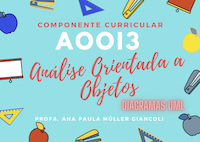

## AULA 07 - DIAGRAMA DE CLASSES DE DOMÍNIO

### Agenda

- AOO: Análise Orientada a Objetos
- POO: Programação Orientada a Objetos
- Processo Unificado
- O que é Modelo de Domínio?
- Como Criar um modelo de Domínio?
- Exemplos de Categorias
- Classes
- Atributos de uma Classe
- Métodos de uma Classe
- Passagens de Parâmetros
- Convenções
- Modelo de Classes
- Diagrama de Classes
- Características Importantes
- Relacionamentos entre Classes
- Perguntas

### 1. Esteriótipos do Diagrama de Classes

### 1.1. ENTITY

- **Objetivo**: tornar explícito que uma classe é **uma entidade**.
- Contém informações recebidas e armazenada pelo sistema ou geradas por meio deste.
- Essas informações referem-se ao contexto do problema que o software pretende solucionar.
- Existe a possibilidade de objetos dessas classes precisem ser persistidos, preservados fisicamente de alguma maneira.

### 1.2. BOUNDARY

- Conhecido como estereótipo de fronteira.
- **Objetivo**: serve para identificar uma classe que serve de comunicação entre os atores externos e o sistema propriamente dito.
- Muitas vezes é associada a própria interface do sistema.
- Normalmente, necessita interagir com outra classe do tipo - **CONTROL** -.
  - **Importante**: quando há a necessidade de definir a existência de uma interface do sistema.

### 1.3. CONTROL

- **Objetivo**: identifica classes que servem de intermédio entre as classes - **BOUNDARY** - e as demais classes do sistema.
- Os objetos - **CONTROL** - são responsáveis por interpretar os eventos ocorridos sobre os objetos - **BOUNDARY** - , como por exemplo:
  - movimentos do mouse.
  - pressionamento de botões e retransmiti-los aos objetos das classes de entidade que compõem o sistema.

**Figura 1: Representação dos Símbolos de esteriótipos de classes**

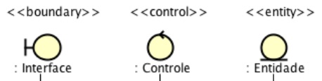

Fonte: Autoria própria

### 2. AOO: Análise Orientada a Objetos x POO: Programação Orientada a Objetos

AOO

POO

- Durante a AOO, há uma ênfase em encontrar e descrever os objetos (ou conceitos) no domínio do problema.  
- **Exemplo**: No caso de um sistema de informação de vôo, são incluídos conceitos tal como: avião, vôo, piloto.

- Durante o POO, há uma ênfase na definição dos objetos de software e como eles colaboram para a satisfação dos requisitos.  
- **Exemplo**: São incluídos conceitos de que um objeto pode ter atributo tal como, numDaCauda e método, obterHistoricoVoo.

**Diagrama de Classes de Domínio** ou **Modelo Conceitual de Objetos**  
- É uma visualização de conceitos ou modelos mentais do domínio do mundo real.  
- Um **modelo de domínio** mostra os conceitos ou objetos do domínio que são de interesse.  
- **Exemplo**: Jogador, Dados, Jogo de Dados com suas associações e atributos.

**Diagramas de Classes de Projeto**  
- Ilustrar os atributos e métodos da classe.  
- O **POO** se preocupa com a definição de objetos de software e suas responsabilidades e colaborações.  
- **Exemplo**: Jogador, Dados, Jogo de Dados com seus respectivos atributos e métodos das classes.

**Figura 2: Representação de Diagrama de Classes de Domínio**

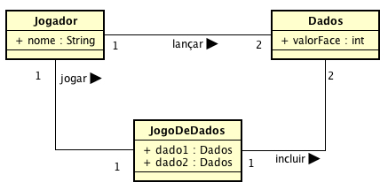

Fonte: Autoria própria

**Figura 3: Representação de Diagrama de Classes de Projeto**

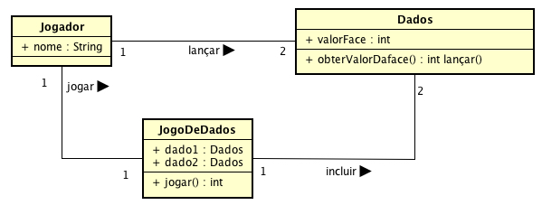

Fonte: Autoria própria

**Diagramas de Sequencias**  
- Mostra o fluxo das mensagens entre os objetos - invocação dos métodos.  
- O **POO** se preocupa com a definição de objetos de software e suas responsabilidades e colaborações.  
- **Exemplo**: Jogador, Dados, Jogo de Dados com a troca de mensagens entre eles.

**Figura 4: Representação de Diagrama de Sequencias**

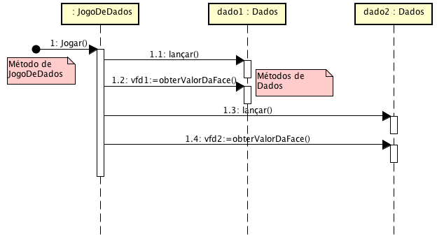

Fonte: Autoria própria

**Processo Unificado (PU)**  
**Classes Conceituais / Modelo de Domínio**  
- O **modelo de domínio** mostra uma perspectiva conceitual.  
- No PU quando as **caixas UML** são desenhadas no modelo de domínio, elas **são chamadas de conceitos de domínio ou classes conceituais**.

**Processo Unificado (PU)**  
**Classes de Projeto ou Modelo de Projeto**  
- O **modelo de projeto** mostra uma perspectiva de especificação ou implementação, conforme desejado pelo modelador.  
- No PU quando as **caixas de UML** são desenhadas no modelo de projeto, elas **são chamadas de classes de projeto**.

**Modelo de Domínio PU**  
**Figura 5: Representação de Diagrama de Classes de Domínio PU**

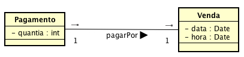

Fonte: Autoria própria

**Modelo de Projeto PU**  
**Figura 6: Representação de Diagrama de Classes de Projeto PU**

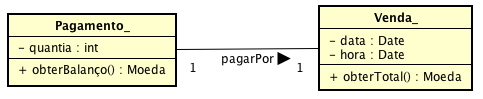

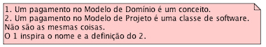

Fonte: Autoria própria

### 3. O que é Modelo de Domínio ?

- Um **modelo de domínio** é uma representação visual de **classes conceituais, ou objetos do mundo real em um domínio**.
- Modelos de domínio também têm sido **chamados de modelos conceituais, modelos de objetos do domínio e modelo de objetos da análise**.
- Um modelo de domínio é ilustrado com **um conjunto de diagramas de classes em que nenhuma operação (assinatura do método) é definida**.
- **Perspectiva conceitual**.
- Pode mostrar:
  - **objetos** do domínio ou classes conceituais.
  - **associações** entre classes conceituais.
  - **atributos** de classes conceituais.
- Não deve mostrar:
  - **artefatos** de software:
    - como uma janela ou um banco de dados.
    - responsabilidades ou métodos.
- Um **modelo de domínio não é um modelo de dados** (que por definição mostra os dados persistentes a serem armazenados em algum lugar).
- É válido ter **classes conceituais sem atributos** ou classes conceituais que tenham um papel simplesmente comportamental no domínio, em vez de um papel de informação.

### 4. Como criar um Modelo de Domínio ?

- 1.Encontre as classes conceituais: reusar ou modificar modelos existentes.
- 2.Usar listas de categorias.
- 3.Identificar substantivos ou frases nominais.
- 4.Faça seu desenho como classes em um diagrama de classes UML.
- 5.Acrescente as associações e atributos.

### 4.1. Exemplos de Categorias

- **Transações de negócio**: Venda, Pagamento, Reserva. Transações de linhas de item: LinhaDeItemDeVenda.
- **Produtos ou serviços relacionados com uma transação**: Item, Vôo, Lugar, Refeição.
- **Onde a transação é registrada?** : Registradora, LivroDiário, ManifestoDeVôo.
- **Papéis de pessoas ou organizações relacionadas à transação; atores no caso de uso**: Caixa, Cliente, Loja, Jogador, Passageiro, LinhaAerea.
- **Local da transação, local do serviço**: Loja, Aeroporto, Avião, Lugar.
- **Eventos notáveis, frequentemente com uma hora ou local que precisamos lembrar**: Venda, Pagamento, Vôo.
- **Objetos físicos**: Itens, Registro, Tabuleiro, Peça, Dado, Avião.
- **Descrição de coisas**: DescriçãoDoProduto, DescriçãoDeVôos.
- **Catálogos**: CatálogoDeProdutos, CatálogoDeVendas.
- **Conteiner de coisas**: Loja, Prateleira, Tabuleiro, Avião.
- **Coisas em um conteiner**: Item, Casa(tabuleiro), Passageiro.
- **Outros sistemas colaboradores**: SistemaDeAutorizaçãoDeCrédito, ControleDeTráfegoAéreo.
- **Registros de finanças, trabalho, contrato, assuntos legais**: Recibo, LivroDiário, RegistroDeManutenção.
- **Instrumentos financeiros**: DinheiroEmEspécie, Cheque, LinhaDeCrédito, TiqueteDeCrédito.
- **Horários, manuais, documentos consultados regularmente para realizar trabalho**: ListaDiáriaDeModificaçãoDePreço, CronogramaDeReparo.

### 5. Classes

- É **um tipo definido pelo usuário que possui especificações**.
- Especificações são as **características e comportamentos** que o identifi quem.
- Utiliza-se as classes para capturar o vocabulário do sistema que está sendo desenvolvido.
- Permite representar uma abstração independente da linguagem de programação.
- Uma **classe é representada graficamente por um retângulo dividido em 3 parte**:
  - Nome da classe
  - Atributos da classe
  - Métodos da classe

**Figura 7: Representação de uma Classe**

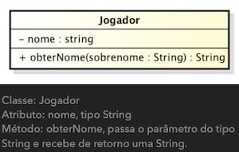

Fonte: Autoria própria

### 5.1. Atributos de uma Classe

- As definições das características de um objeto são feitas através de atributos da classe.
- **Atributos armazenam os dados do objeto**.
- **Exemplo**: dados de Identificação (camiseta, calça, etc.), dados de preço (18,00, 60,00, etc).
- Declaramos atributos dentro da declaração da classe. Quando declaramos um atributo de uma classe indicamos o tipo de dado que será armazenado nele.

### 5.2. Métodos de uma Classe

- Através dos métodos definimos as operações que podem ser executadas com ou sobre um objeto. (comportamento da classe).
- São declarados dentro do corpo da classe:
  - Retorno do método.
  - Nome do método.
  - Parâmetro do método.

### 5.3. Passagem de Parâmetros

- Os parâmetros de um método devem ser declarados separadamente, usando-se vírgulas entre os parênteses da assinatura do método.
- Em chamadas a métodos é obrigatório passar os parâmetros usando os mesmos tipos definidos em sua assinatura, caso contrário o compilador acusará um erro.
- Variáveis são SEMPRE passadas através de uma cópia de seu valor.

### 5.4. Convenções

- Para **nomes das Classes**:
  - Primeira letra maiúscula. Se composto, as iniciais de cada palavra em maiúsculo.
- Para **nomes de Atributos** das classes:
  - Letras minúsculas. Quando o nome for composto por duas ou mais palavras, a separação deve ser feita com caracter maiúsculo.
- Para **nomes de Métodos** das classes:
  - Letras minúsculas. Quando o nome for composto por duas ou mais palavras, a separação de deve ser feita com caracter maiúsculo. Usar verbos no infinitivo.

### 6. Modelo de Classes

- É importante notar que o modelo de classes é utilizado durante a maior parte do desenvolvimento interativo.
- Evolui ao longo do desenvolvimento do sistema, sendo incrementado de novos detalhes.
- Para tal há 3 estágios de abstração:
- 1.Análise
- 2.Especificação
- 3.Implementação

### 6.1. Modelo de Classes: Análise

- A atenção é voltada para "o que" o sistema deve fazer.
- Não leva em consideração a tecnologia a ser utilizada na solução do problema.
- Casos de uso e modelos de classe são os 2 principais modelos criados na fase de Análise.

### 6.2. Modelo de Classes: Especificação

- A atenção é voltada para "como" o sistema deve funcionar.
- É um detalhamento do modelo de classes de análise.

### 6.3. Modelo de Classes: Implementação

- É um detalhamento do modelo de classes de especificação.
- É a implementação das classes em uma linguagem de programação.

### 7. Diagramas de Classes

- É utilizado na construção do modelo de classes desde o nível de análise até o nível de especificação.
- É o diagrama mais rico em termos de notação.
- No diagrama de classes podemos representar a existência de relacionamentos entre os objetos.
- Para relacioná-los, utilizamos a notação de associação. Por exemplo:
  - um cliente compra produtos.
  - uma conta corrente possui um histórico de transações.
  - um hotel tem vários hóspedes, como qualquer quarto são ocupados por hóspedes.

### 7.1. Exemplos Conceituais sem Indicação Multiplicidades

**Figura 8: Representação de Classes Conceituais**

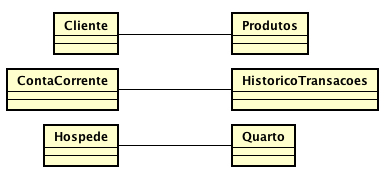

Fonte: Autoria própria

- Quando ligamos uma classe na outra por associação, estamos informando que há uma troca de mensagens entre os objetos destas classes.
- E que eles podem colaborar entre si para realizar alguma tarefa do sistema

### 8. Características Importantes

### 8.1. Multiplicidade

- Indicam os limites inferiores e superiores da quantidade de objetos aos quais outro objeto pode estar associado.
- Existe nos dois sentidos.
- Um em cada extremidade.  
  **Figura 9: Representação da Multiplicidade**

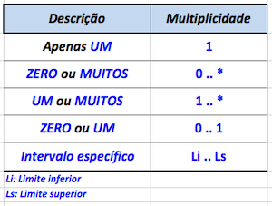

  Fonte: Autoria própria

### 8.2. Conectividade

- A conectividade é associação entre duas classes e depende dos símbolos de multiplicidade que são utilizados na associação.  
  **Figura 10: Representação da Multiplicidade**

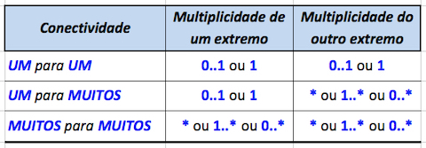

  Fonte: Autoria própria

**Figura 11: Um empregado pode gerenciar um e somente um departamento**

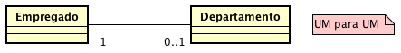

Fonte: Autoria própria

**Figura 12: Um empregado está lotado em um único departamento, mas um departamento pode ter diversos empregados**

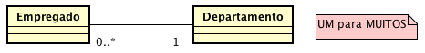

Fonte: Autoria própria

**Figura 13: Um projeto pode ter diversos empregados como trabalhadores. E um empregado pode trabalhar em diversos departamentos e projetos**

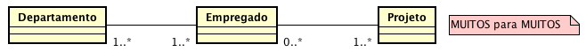

Fonte: Autoria própria

### 8.3. Tipo de Participação

- É uma característica importante de uma associação que está relacionada à necessidade ou não da existência dessa associação entre os objetos. A participação pode ser obrigatória ou opcional.
- Se o valor mínimo da multiplicidade é 1 (um), logo a participação é obrigatória.

**Figura 14: A multiplicidade de valor 1 do lado do Empregado indica que um objeto da classe Departamento só pode existir associado a um objeto da classe empregado.**

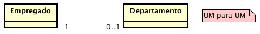

Fonte: Autoria própria

- Para os **objetos da classe Departamento** a participação é **obrigatória**.
- Para os **objetos da classe Empregado** a participação é **parcial** (pode haver empregados que não estejam associados a Departamentos, indicado pelo símbolo 0..1).
- **Importante**:
  - Deve-se ter o cuidado com a utilização das participações obrigatórias, pois “engessam" o modelo, o que dificulta futuras extensões do mesmo.
  - Se há dúvida, deixe para mais tarde quando se conhece melhor e se tem maiores detalhes do sistema.

### 8.4. Nome, direção de leitura e papéis

- Para melhor esclarecer o significado de uma associação, utilizaremos:
  - **nome da associação**: simples e com significado. Clareza e concisão.
  - **direção de leitura** (seta indicativa da direção da leitura).
  - **papéis** (nomeação dos papéis).

**Figura 15: Nome, direção de leitura e papéis**

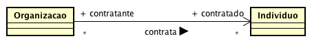

Fonte: Autoria própria

- **EMBORA NÃO SEJA USUAL, MAS PODE HAVER MOTIVOS PELOS QUAIS UM OBJETO PRECISA SABER SOBRE OUTRO**.
- **ENTRE DUAS CLASSES PODE HAVER MAIS ASSOCIAÇÕES**.  
  **Figura 16: Nome, direção de leitura e papéis**

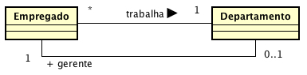

  Fonte: Autoria própria

### 8.5. Qualificação

- Se um atributo de associação é único dentro de um conjunto de objetos relacionados, então ele é um qualificador.
- Um qualificador é um valor que seleciona um objeto exclusivo do conjunto de objetos relacionados em uma associação.
- Tabelas e matrizes de pesquisa podem ser modeladas como associações qualificadas.
- Qualificadores são importantes para modelar nomes e códigos de identificação.
- Os Qualificadores também modelam índices em um modelo de design.  
  **Figura 17: Os atributos performance e assento são únicos, qualificadores dentro os objetos de Show**

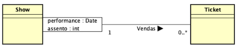

  Fonte: Autoria própria

### 9. Relacionamentos entre Classes

- Os relacionamentos ligam as classes/objetos entre si criando relações lógicas entre estas entidades.
- Os relacionamentos podem ser dos seguintes tipos:
  - Associação.
  - Agregação.
  - Composição.
  - Dependência.
  - Generalização.

### 9.1. Associação

- É uma conexão entre classes, e também significa que é uma conexão entre objetos daquelas classes.
- Em UML, uma associação é definida com um relacionamento que descreve uma série de ligações, onde a ligação é definida como a semântica entre as duplas de objetos ligados.
- Ocorre quando temos uma classe que possui um atributo de outra classe (objetos ou array de objetos).
- Permite que os objetos comuniquem entre si.
- **Representa**: que duas classes possuem uma ligação (link) entre elas.
- **Tipo**: mais comum de associação é apenas uma conexão entre classes.
- **Representada**: por uma linha sólida entre duas classes.
- **Possui**: um nome (junto à linha que representa a associação), normalmente um verbo, mas substantivos também são permitidos.
- **Pode-se**: também colocar uma seta no final da associação indicando que esta só pode ser usada para o lado onde a seta aponta.  
  **Figura 18: Relacionamento de Associação**

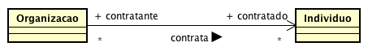

  Fonte: Autoria própria

### 9.1.1. Tipos de Associação

- Classes Associativas.
- Associações Reflexivas.
- Associações Ternárias.
- Agregações ou Composições.

### 9.1.1.1. Classes Associativas

- **São**: as classes que estão ligadas a associações, ao invés de estarem ligadas a outras classes.
- Esse tipo de classe normalmente aparece quando duas ou mais classes estão associadas e é necessário manter informações sobre a associação existente entre as mesmas.  
  **Figura 19: Relacionamento de Classes Associativas**

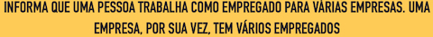

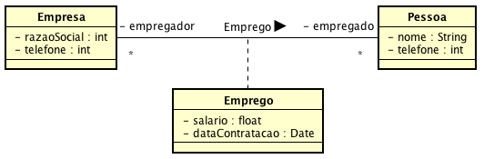

  Fonte: Autoria própria
- A classe associativa **[Emprego]** permite saber, para **cada par de objetos [empregado, empregador]**, qual é o **salário e a data de contratação** do empregado em relação à aquele empregador.

**Figura 20: Relacionamento de Classes Associativas**

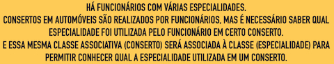

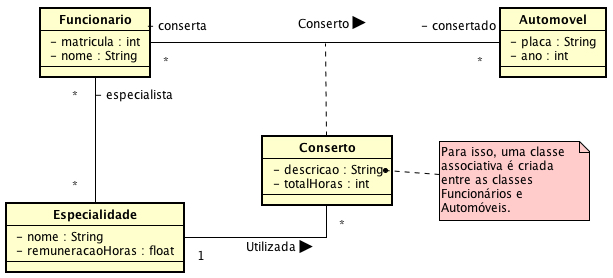

Fonte: Autoria própria

- Uma classe associativa pode participar de vários relacionamentos.

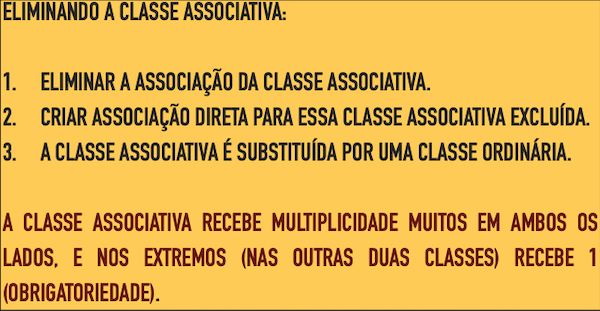

**Figura 21: Relacionamento de Classes Associativas Eliminado e Substituído pela Classe Ordinária**

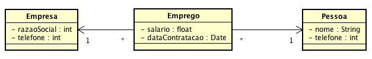

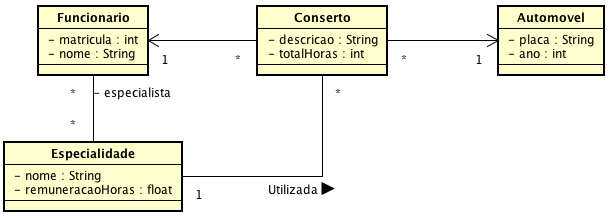

Fonte: Autoria própria

### 9.1.1.2. Associações Reflexivas

- É possível conectar uma classe a ela mesma através de uma associação e que ainda representa semanticamente a conexão entre dois objetos, mas os objetos conectados são da mesma classe.
- Uma associação deste tipo é chamada de **associação recursiva**.
- Há objetos que assumem o papel de supervisor e outros objetos que assumem o papel de supervisionado.